# Changing Nature of Death in Infany in the United States

Kevin Dysart

11/15/2019

## Overview

Using the linked birth and death certificate data collected by the CDC the project aims to evaluate the changing nature of death amongst infants born less than 32 weeks gestation. Increasing use by clinicians of clinical tools and therapeutics that have changed little in the last 20 years combined with a perceived shift in parent attitudes regarding the aggresive the aggresive pursuit of life in this cohort has likely lead to an increasing time before death over the last 20 years.

## Introduction

Infants born less than 32 weeks of completed gestation continue to experience high mortality rates. Amongst infants in this category, those of the lowest gestational ages have the highest risk of mortality. Over the last 20 years, the presence of neonatal intensive care units has made intensive care therapies more available to an increasing number of infants. This availability, in combination with more aggressive support for infants at the youngest gestational ages, is leading to a small increase in survival over time. To this point in neonatal medicine, deaths typically occur early in the lives of infants in this cohort as a consequence of the extreme prematurity of their physiology. They are not able to be supported by current technologies. While the aforementioned increasing survival is well described, it continues to be poorly studied and understood how these shifts in care paradigms are impacting timing to death in infants that do die in infancy.

Extending the lives of infants before their death has a profound impact on a multitude of people, from parents to caregivers to society itself. Parents face life’s greatest challenge, loving and supporting a child through their life and ultimate death. Support systems that currently exist to assist them include parent support groups, social work teams, and in many care settings, psychologic support. A growing pull between what becomes unrealistic parental expectations and the realities of what medical care can and cannot offer develops between the parents and the care team. Continually caring for an infant the team thinks will not ultimately survive places burdens on them that have lasting effects on their ability to care for infants in such settings now and in the future. Provider burnout is contributed to by many factors, but providing futile care is among the causes. Society itself is faced with many issues, including lost economic productivity caused by parental time away from work and the growing cost of care for such infants, to name only two.

## Methods

```r
#X2017_All_Infant_Death_By_State <- read_delim("Linked_Birth_Death_Data/CDC_Wonder_All_Death_By_Year/2017_All_Infant_Death_By_State.txt", "\t", escape_double = FALSE, trim_ws = TRUE)
#`2007_All_Infant_Death_By_State` <- read.delim("~/BMIN503_Final_Project/Linked_Birth_Death_Data/CDC_Wonder_All_Death_By_Year/2007_All_Infant_Death_By_State.txt")

#Reading CDC Wonder Data Files
Wonder_File_Names <- list.files(path = "Linked_Birth_Death_Data/CDC_Wonder_All_Death_By_Year/", pattern = "*.txt")
Wonder_Files <- list.files(path = "Linked_Birth_Death_Data/CDC_Wonder_All_Death_By_Year/", pattern = "*.txt", full.names = T)
Wonder_Files_df <- lapply(Wonder_Files, read.delim)
names(Wonder_Files_df) <- Wonder_File_Names
#Reading Linked Birth and Death Data
Linked_Birth_Death_Names <- list.files(path = "Linked_Birth_Death_Data/Linked_Year_CSV_Zip/", pattern = "*.csv.zip")
Linked_Birth_Death_Files <- list.files(path = "Linked_Birth_Death_Data/Linked_Year_CSV_Zip/", pattern = "*.csv.zip", full.names = T)
Linked_Birth_Death_Files_df <- lapply(Linked_Birth_Death_Files, read_csv)
names(Linked_Birth_Death_Files_df) <- Linked_Birth_Death_Names
```

```r
for (i in 1:length(Wonder_Files_df)) {
  Wonder_Files_df[[i]] <-  Wonder_Files_df[[i]] %>%
                    select(-Notes) %>%
                    slice(1:51)
}
```

## Results

```r
All_Infant_Death_2017_By_State <- Wonder_Files_df[[11]]
All_Infant_Death_2017_By_State <- rename(All_Infant_Death_2017_By_State, state_name = State)
All_Infant_Death_2017_By_State <- rename(All_Infant_Death_2017_By_State, death_rate = "Death.Rate")

state_data_infant_death_2017 <- left_join(All_Infant_Death_2017_By_State, states,
                                          by = "state_name")
```

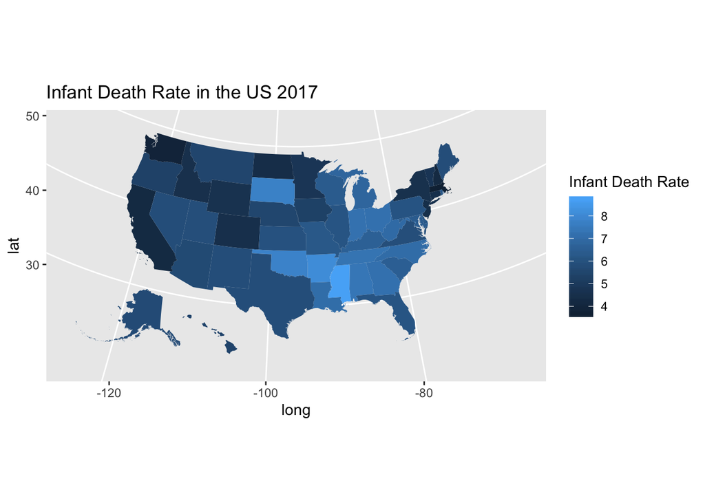

```r
state_data_infant_death_2017 %>%
  ggplot(aes(long, lat, group = group, fill = death_rate)) +
  ggtitle("Infant Death Rate in the US 2017") +
  geom_polygon(color = NA) +
  coord_map(projection = "albers", lat0 = 39, lat1 = 45) +
  labs(fill = "Infant Death Rate")
```